# Robustness Check: Age Investigation

2026-11-22

Section 0 describes how age, symptom severity, and self-labeling relate in the observed data, in both study periods. Two age findings in `Main Analysis.Rmd` then prompt the rest of this investigation:

1. In the secondary analyses (PIH), older participants self-label more at the same symptom severity (risk ratio for age 60 vs. 20 at DASS = 8.5: about 1.57).
2. In moderation analyses, the age x year interaction depends on whether age is allowed to differ by dataset.

A likely confounder is reason for visiting the website: younger participants are much more often completing a school assignment. This document (1) checks the primary analysis controlling for `referral_recoded`, (2) checks whether the age association survives adjustment and stratification, (3) examines age in bins, and (4) examines the age x year interaction with tests that do not depend on `D1()`.

`referral_recoded` exists in PIH only, so sections 1-3 use PIH. Analyses use imputed `referral_recoded`; versions marked “observed referral” restrict to participants who answered the referral question.

```r
library(here)
library(knitr)
library(kableExtra)
library(scales)
library(mice)
library(marginaleffects)
library(tidyverse)
`%+%` <- paste0

source(here("Helper Functions", "Analysis Functions.R"))

pimh_ni <- readRDS(here("Data", "PIMH - 2012-2019", "pimh_with_geo.rds"))
pih_ni <- readRDS(here("Data", "PIH - 2019-Current", "pih_with_geo.rds"))
all_ni <- bind_rows(pimh_ni, pih_ni)
pimh_c <- readRDS(here("Data", "PIMH - 2012-2019", "pimh_completed.rds"))
pih_c <- readRDS(here("Data", "PIH - 2019-Current", "pih_completed.rds"))
all_c <- readRDS(here("Data", "PIMH + PIH Combined", "all_completed.rds"))

# PIH participants who answered the referral question (completed data keep the original row order)
pih_c_observed <- map(pih_c, ~ filter(.x, !is.na(pih_ni$referral_recoded)))
```

## 0. Age, Symptom Severity, and Self-Labeling (Observed Data)

```r
study_period_labels <- c("PIMH" = "First Study Period (2016-2019)", "PIH" = "Second Study Period (2019-2026)")

age_descriptives <- all_ni %>%
  filter(!is.na(age)) %>%
  mutate(
    study_period = fct(study_period_labels[dataset], levels = study_period_labels),
    age_group = cut(age, c(17, 19, 22, 24, 29, 39, 49, 59, Inf), labels = c("18-19", "20-22", "23-24", "25-29", "30-39", "40-49", "50-59", "60+"))
  )
```

### 0.1. Symptom Severity and Self-Labeling, by Age

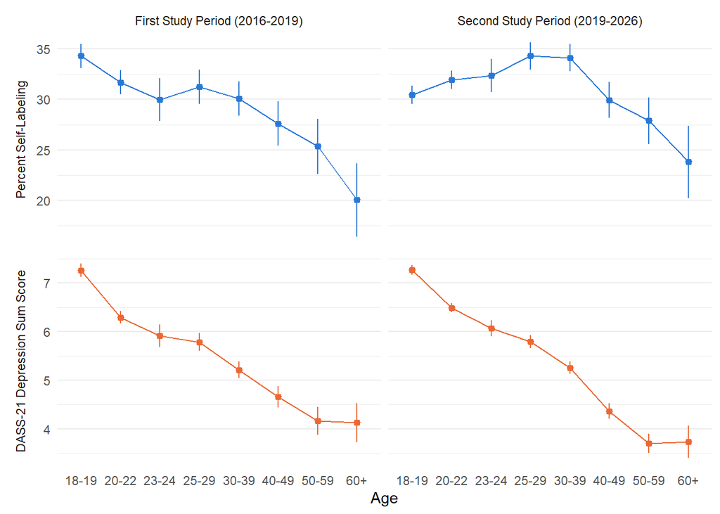

```r
age_descriptives %>%
  mutate(`Percent Self-Labeling` = 100 * dep_self_label_now, `DASS-21 Depression Sum Score` = depression_sum) %>%
  pivot_longer(c(`Percent Self-Labeling`, `DASS-21 Depression Sum Score`), names_to = "measure", values_to = "value") %>%
  summarize(
    estimate = mean(value, na.rm = T),
    se = sd(value, na.rm = T) / sqrt(sum(!is.na(value))),
    .by = c(study_period, measure, age_group)
  ) %>%
  mutate(measure = fct(measure, levels = c("Percent Self-Labeling", "DASS-21 Depression Sum Score"))) %>%
  ggplot(aes(x = age_group, y = estimate, color = measure, group = measure)) +
  geom_line(linewidth = .5) +
  geom_pointrange(aes(ymin = estimate - qnorm(.975) * se, ymax = estimate + qnorm(.975) * se), size = .3) +
  facet_grid(measure ~ study_period, scales = "free_y", switch = "y") +
  scale_color_manual(values = c("Percent Self-Labeling" = "#2a78d6", "DASS-21 Depression Sum Score" = "#eb6834"), guide = "none") +
  labs(x = "Age", y = NULL) +
  theme_minimal() +
  theme(strip.placement = "outside", panel.grid.major.x = element_blank())
```

### 0.2. Symptom Severity by Age, Compared with the US Population

NHANES (August 2021-August 2023) reports the percentage of US adults with PHQ-9 scores of 10 or more, by age (NCHS Data Brief No. 527). This sample uses the DASS-21, so the comparison is of the age pattern, not the level: the percentage with DASS-21 depression scores of 7 or more (“moderate” or worse) in this sample during the same years, each relative to ages 20-39.

```r
all_ni %>%
  filter(year %in% 2021:2023, age >= 20) %>%
  mutate(age_group = cut(age, c(19, 39, 59, Inf), labels = c("20-39", "40-59", "60+"))) %>%
  summarize(this_sample = 100 * mean(depression_sum >= 7, na.rm = T), n = n(), .by = age_group) %>%
  arrange(age_group) %>%
  mutate(nhanes = c(16.6, 10.8, 8.7)) %>% # NHANES prevalence (%) by age group
  mutate(across(c(this_sample, nhanes), ~ .x / first(.x), .names = "{.col}_relative")) %>%
  select(age_group, n, this_sample, this_sample_relative, nhanes, nhanes_relative) %>%
  kable(digits = 2, col.names = c("Age", "n (this sample)", "% DASS-21 7+", "Relative", "NHANES % PHQ-9 10+", "Relative")) %>%
  kable_styling()
```

| Age | n (this sample) | % DASS-21 7+ | Relative | NHANES % PHQ-9 10+ | Relative |
| --- | --- | --- | --- | --- | --- |
| 20-39 | 9754 | 42.69 | 1.00 | 16.6 | 1.00 |
| 40-59 | 1691 | 23.00 | 0.54 | 10.8 | 0.65 |
| 60+ | 248 | 20.16 | 0.47 | 8.7 | 0.52 |

### 0.3. Self-Labeling by Symptom Severity and Age

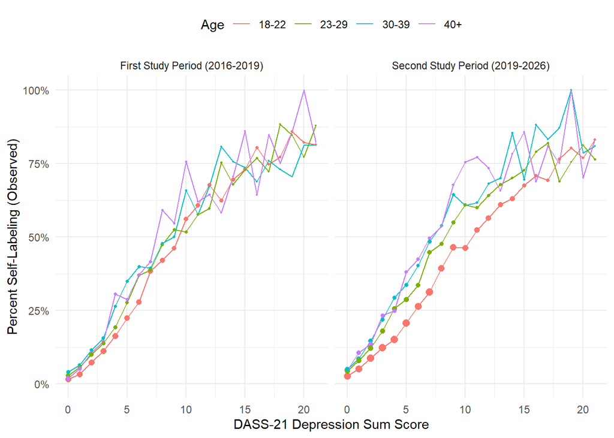

```r
age_descriptives %>%
  mutate(age_group = fct_collapse(age_group, "18-22" = c("18-19", "20-22"), "23-29" = c("23-24", "25-29"), "40+" = c("40-49", "50-59", "60+"))) %>%
  summarize(self_labeling = mean(dep_self_label_now, na.rm = T), n = n(), .by = c(study_period, age_group, depression_sum)) %>%
  ggplot(aes(x = depression_sum, y = self_labeling, color = age_group)) +
  geom_line() +
  geom_point(aes(size = n), show.legend = F) +
  facet_wrap(~ study_period) +
  scale_y_continuous(labels = label_percent(), limits = c(0, 1)) +
  scale_size_area(max_size = 2.5) +
  labs(x = "DASS-21 Depression Sum Score", y = "Percent Self-Labeling (Observed)", color = "Age") +
  theme_minimal() +
  theme(legend.position = "top")
```

### 0.4. Age and Reason for Visiting

```r
pih_ni %>%
  filter(!is.na(referral_recoded)) %>%
  mutate(age_group = cut(age, c(17, 22, 24, 29, 39, Inf), labels = c("18-22", "23-24", "25-29", "30-39", "40+"))) %>%
  filter(!is.na(age_group)) %>%
  count(age_group, referral_recoded) %>%
  mutate(pct = 100 * n / sum(n), .by = age_group) %>%
  select(-n) %>%
  pivot_wider(names_from = referral_recoded, values_from = pct) %>%
  kable(digits = 1, caption = "Reason for visiting, % within age group") %>%
  kable_styling()
```

Reason for visiting, % within age group

| age_group | Assignment for school | Assignment for work | Other |
| --- | --- | --- | --- |
| 18-22 | 90.2 | 2.2 | 7.6 |
| 23-24 | 81.6 | 7.8 | 10.5 |
| 25-29 | 75.0 | 11.6 | 13.4 |
| 30-39 | 63.7 | 18.6 | 17.6 |
| 40+ | 45.5 | 30.0 | 24.6 |

## 1. Primary Analysis, Controlling for Reason for Visiting (PIH)

```r
pih_model_base <- "dep_self_label_now ~ poly(depression_sum, 3, raw = TRUE) + decimal_year_centered + age + race_recoded + gender + education"

primary_referral <- tribble(
  ~model,                                    ~data,          ~formula,
  "Primary",                                 pih_c,          pih_model_base,
  "Primary + referral",                      pih_c,          pih_model_base %+% " + referral_recoded",
  "Primary + referral (observed referral)",  pih_c_observed, pih_model_base %+% " + referral_recoded",
  "Primary + referral x year",               pih_c,          pih_model_base %+% " + referral_recoded * decimal_year_centered"
) %>%
  mutate(ratios = map2(data, formula, ~ fit_models(.x, as.formula(.y)) %>% risk_ratios() %>% as_tibble()))

primary_referral %>%
  select(model, ratios) %>%
  unnest(ratios) %>%
  select(model, depression_sum, estimate, conf.low, conf.high) %>%
  kable(digits = 3, caption = "Risk ratio per year, PIH") %>%
  kable_styling()
```

Risk ratio per year, PIH

| model | depression_sum | estimate | conf.low | conf.high |
| --- | --- | --- | --- | --- |
| Primary | 5.5 | 1.029 | 1.020 | 1.038 |
| Primary | 8.5 | 1.021 | 1.015 | 1.028 |
| Primary | 12.0 | 1.015 | 1.011 | 1.020 |
| Primary + referral | 5.5 | 1.024 | 1.015 | 1.033 |
| Primary + referral | 8.5 | 1.018 | 1.011 | 1.024 |
| Primary + referral | 12.0 | 1.013 | 1.008 | 1.017 |
| Primary + referral (observed referral) | 5.5 | 1.034 | 1.022 | 1.046 |
| Primary + referral (observed referral) | 8.5 | 1.024 | 1.016 | 1.033 |
| Primary + referral (observed referral) | 12.0 | 1.017 | 1.011 | 1.024 |
| Primary + referral x year | 5.5 | 1.024 | 1.015 | 1.033 |
| Primary + referral x year | 8.5 | 1.018 | 1.011 | 1.024 |
| Primary + referral x year | 12.0 | 1.013 | 1.008 | 1.017 |

## 2. Age Association: Adjustment and Stratification (PIH)

Risk ratio for age 60 vs. 20 at DASS = 8.5, as in `Main Analysis.Rmd` section 3.1.

```r
secondary_base <- "dep_self_label_now ~ poly(depression_sum, 3, raw = TRUE) + age"
demographics <- " + race_recoded + gender + education"

age_ratio <- function(data, formula) {
  fit_models(data, as.formula(formula)) %>%
    risk_ratios(variables_to_calculate = list(age = c(20, 60)), severity = 8.5) %>%
    as_tibble()
}

school <- function(data) map(data, ~ filter(.x, referral_recoded == "Assignment for school"))
not_school <- function(data) map(data, ~ filter(.x, referral_recoded != "Assignment for school"))

age_adjusted <- tribble(
  ~model,                                       ~data,                      ~formula,
  "Age only (as in 3.1)",                       pih_c,                      secondary_base,
  "Age + referral",                             pih_c,                      secondary_base %+% " + referral_recoded",
  "Age + demographics",                         pih_c,                      secondary_base %+% demographics,
  "Age + referral + demographics",              pih_c,                      secondary_base %+% " + referral_recoded" %+% demographics,
  "Age + referral + demographics + year",       pih_c,                      secondary_base %+% " + referral_recoded" %+% demographics %+% " + decimal_year_centered",
  "School assignment only",                     school(pih_c),              secondary_base,
  "Not school assignment",                      not_school(pih_c),          secondary_base,
  "School assignment only (observed referral)", school(pih_c_observed),     secondary_base,
  "Not school assignment (observed referral)",  not_school(pih_c_observed), secondary_base,
  "PIMH (no referral data), age only",          pimh_c,                     secondary_base
) %>%
  mutate(ratios = map2(data, formula, age_ratio))

age_adjusted %>%
  select(model, ratios) %>%
  unnest(ratios) %>%
  select(model, contrast, estimate, conf.low, conf.high, p.value) %>%
  kable(digits = 3) %>%
  kable_styling()
```

| model | contrast | estimate | conf.low | conf.high | p.value |
| --- | --- | --- | --- | --- | --- |
| Age only (as in 3.1) | ln(mean(60) / mean(20)) | 1.566 | 1.511 | 1.623 | 0 |
| Age + referral | ln(mean(60) / mean(20)) | 1.647 | 1.587 | 1.709 | 0 |
| Age + demographics | ln(mean(60) / mean(20)) | 1.523 | 1.456 | 1.592 | 0 |
| Age + referral + demographics | ln(mean(60) / mean(20)) | 1.569 | 1.501 | 1.641 | 0 |
| Age + referral + demographics + year | ln(mean(60) / mean(20)) | 1.558 | 1.490 | 1.630 | 0 |
| School assignment only | ln(mean(60) / mean(20)) | 1.786 | 1.718 | 1.858 | 0 |
| Not school assignment | ln(mean(60) / mean(20)) | 1.447 | 1.326 | 1.578 | 0 |
| School assignment only (observed referral) | ln(mean(60) / mean(20)) | 1.720 | 1.636 | 1.807 | 0 |
| Not school assignment (observed referral) | ln(mean(60) / mean(20)) | 1.407 | 1.270 | 1.559 | 0 |
| PIMH (no referral data), age only | ln(mean(60) / mean(20)) | 1.240 | 1.173 | 1.310 | 0 |

## 3. Age in Bins (PIH)

Binned comparison as specified (18-22 vs. 25+, excluding 23-24), plus finer bins to show the shape of the association. Risk ratios are relative to the youngest bin, at DASS = 8.5.

```r
add_bins <- function(data) {
  map(data, ~ mutate(
    .x,
    age_binary = fct(case_when(age <= 22 ~ "18-22", age >= 25 ~ "25+"), levels = c("18-22", "25+")),
    age_group = cut(age, c(17, 22, 24, 29, 39, Inf), labels = c("18-22", "23-24", "25-29", "30-39", "40+"))
  ))
}

pih_c_binned <- add_bins(pih_c)

bin_ratio <- function(data, formula, variable) {
  fit_models(data, as.formula(formula)) %>%
    risk_ratios(variables_to_calculate = set_names(list("reference"), variable), severity = 8.5) %>%
    as_tibble()
}

age_binned <- tribble(
  ~model,                                ~data,                                                    ~formula,                                                                                  ~variable,
  "18-22 vs. 25+",                       map(pih_c_binned, ~ filter(.x, !is.na(age_binary))),      "dep_self_label_now ~ poly(depression_sum, 3, raw = TRUE) + age_binary",                               "age_binary",
  "18-22 vs. 25+, + referral",           map(pih_c_binned, ~ filter(.x, !is.na(age_binary))),      "dep_self_label_now ~ poly(depression_sum, 3, raw = TRUE) + age_binary + referral_recoded",            "age_binary",
  "18-22 vs. 25+, school only",          school(map(pih_c_binned, ~ filter(.x, !is.na(age_binary)))), "dep_self_label_now ~ poly(depression_sum, 3, raw = TRUE) + age_binary",                            "age_binary",
  "18-22 vs. 25+, not school",           not_school(map(pih_c_binned, ~ filter(.x, !is.na(age_binary)))), "dep_self_label_now ~ poly(depression_sum, 3, raw = TRUE) + age_binary",                        "age_binary",
  "Five age groups",                     pih_c_binned,                                             "dep_self_label_now ~ poly(depression_sum, 3, raw = TRUE) + age_group",                                "age_group",
  "Five age groups, + referral",         pih_c_binned,                                             "dep_self_label_now ~ poly(depression_sum, 3, raw = TRUE) + age_group + referral_recoded",             "age_group"
) %>%
  mutate(ratios = pmap(list(data, formula, variable), bin_ratio))

age_binned %>%
  select(model, ratios) %>%
  unnest(ratios) %>%
  select(model, contrast, estimate, conf.low, conf.high, p.value) %>%
  kable(digits = 3) %>%
  kable_styling()
```

| model | contrast | estimate | conf.low | conf.high | p.value |
| --- | --- | --- | --- | --- | --- |
| 18-22 vs. 25+ | ln(mean(25+) / mean(18-22)) | 1.370 | 1.333 | 1.409 | 0 |
| 18-22 vs. 25+, + referral | ln(mean(25+) / mean(18-22)) | 1.404 | 1.364 | 1.446 | 0 |
| 18-22 vs. 25+, school only | ln(mean(25+) / mean(18-22)) | 1.422 | 1.377 | 1.468 | 0 |
| 18-22 vs. 25+, not school | ln(mean(25+) / mean(18-22)) | 1.337 | 1.225 | 1.460 | 0 |
| Five age groups | ln(mean(23-24) / mean(18-22)) | 1.176 | 1.120 | 1.235 | 0 |
| Five age groups | ln(mean(25-29) / mean(18-22)) | 1.298 | 1.249 | 1.348 | 0 |
| Five age groups | ln(mean(30-39) / mean(18-22)) | 1.390 | 1.340 | 1.441 | 0 |
| Five age groups | ln(mean(40+) / mean(18-22)) | 1.426 | 1.373 | 1.480 | 0 |
| Five age groups, + referral | ln(mean(23-24) / mean(18-22)) | 1.188 | 1.131 | 1.248 | 0 |
| Five age groups, + referral | ln(mean(25-29) / mean(18-22)) | 1.322 | 1.272 | 1.373 | 0 |
| Five age groups, + referral | ln(mean(30-39) / mean(18-22)) | 1.430 | 1.378 | 1.484 | 0 |
| Five age groups, + referral | ln(mean(40+) / mean(18-22)) | 1.494 | 1.437 | 1.554 | 0 |

## 4. Age x Year Interaction

Pooled estimates of the `age:decimal_year_centered` term (log-odds per year of age per year of time). These per-term tests use the pooled coefficient and are not affected by the `D1()` denominator df problem at small m.

```r
base <- "dep_self_label_now ~ poly(depression_sum, 3, raw = TRUE) + decimal_year_centered + age + race_recoded + gender + education"

age_by_year <- tribble(
  ~model,                                   ~data,  ~formula,
  "PIMH",                                   pimh_c, base,
  "PIH",                                    pih_c,  base,
  "PIH, + referral",                        pih_c,  base %+% " + referral_recoded",
  "PIH, + referral x year",                 pih_c,  base %+% " + referral_recoded * decimal_year_centered",
  "Combined",                               all_c,  base %+% " + dataset",
  "Combined, + age x dataset",              all_c,  base %+% " + dataset + dataset:age"
) %>%
  mutate(
    formula = formula %+% " + age:decimal_year_centered",
    term = map2(data, formula, ~ fit_models(.x, .y) %>% pooled_coefficients() %>% filter(term %in% c("decimal_year_centered:age", "age:decimal_year_centered")))
  )

age_by_year %>%
  select(model, term) %>%
  unnest(term) %>%
  kable(digits = 4) %>%
  kable_styling()
```

| model | term | estimate | p.value | conf.low | conf.high |
| --- | --- | --- | --- | --- | --- |
| PIMH | decimal_year_centered:age | -0.0003 | 0.8552 | -4e-03 | 0.0033 |
| PIH | decimal_year_centered:age | 0.0013 | 0.0422 | 0e+00 | 0.0026 |
| PIH, + referral | decimal_year_centered:age | 0.0011 | 0.0949 | -2e-04 | 0.0023 |
| PIH, + referral x year | decimal_year_centered:age | 0.0011 | 0.1223 | -3e-04 | 0.0025 |
| Combined | decimal_year_centered:age | 0.0027 | 0.0000 | 2e-03 | 0.0035 |
| Combined, + age x dataset | decimal_year_centered:age | 0.0011 | 0.0658 | -1e-04 | 0.0023 |

## 5. Compare to Ahuvia 2026 Screener Data

These data - depression self-labeling, depression symptom severity, and age - are also assessed in a 2026 study with CloudResearch participants (https://osf.io/egxhk). That study included ~4,000 respondents aged 18-29. Does the same age effect appear there?

```r
replication_data <- here("..", "symptom-feedback-study", "Data", "Symptom Feedback Study Screener - Response Data.csv") %>%
  read_csv(
    col_select = c(
      consent = consent_t0,
      age = age_t0,
      self_label_now = self_label_pres_t0,
      self_label_past = self_label_past_t0,
      diagnosis = diagnosis_t0,
      treatment_now = treatment_pres_t0,
      treatment_past = treatment_past_t0,
      treatment_seeking = treatment_seeking_t0,
      "phq_8_t1_" %+% 1:8
    )
  ) %>%
  filter(
    consent == "I agree",
    age %in% 18:29
  ) %>%
  mutate(
    age = as.numeric(age),
    across(
      all_of("phq_8_t1_" %+% 1:8),
      ~ case_match(
        .,
        "Not at all" ~ 0,
        "Several days" ~ 1,
        "More than half the days" ~ 2,
        "Nearly every day" ~ 3
      )
    ),
    phq_8_sum = phq_8_t1_1 + phq_8_t1_2 + phq_8_t1_3 + phq_8_t1_4 + phq_8_t1_5 + phq_8_t1_6 + phq_8_t1_7 + phq_8_t1_8
  )
model <- glm(
  data = replication_data,
  formula = (self_label_now == "Yes") ~ phq_8_sum + age,
  family = "binomial"
)

summary(model)
```

```
##
## Call:
## glm(formula = (self_label_now == "Yes") ~ phq_8_sum + age, family = "binomial",
##     data = replication_data)
##
## Coefficients:
##              Estimate Std. Error z value Pr(>|z|)
## (Intercept) -6.149839   0.365665 -16.818   <2e-16 ***
## phq_8_sum    0.319101   0.009803  32.551   <2e-16 ***
## age          0.114981   0.013549   8.486   <2e-16 ***
## ---
## Signif. codes:  0 '***' 0.001 '**' 0.01 '*' 0.05 '.' 0.1 ' ' 1
##
## (Dispersion parameter for binomial family taken to be 1)
##
##     Null deviance: 5443.4  on 3986  degrees of freedom
## Residual deviance: 3468.1  on 3984  degrees of freedom
##   (23 observations deleted due to missingness)
## AIC: 3474.1
##
## Number of Fisher Scoring iterations: 5
```

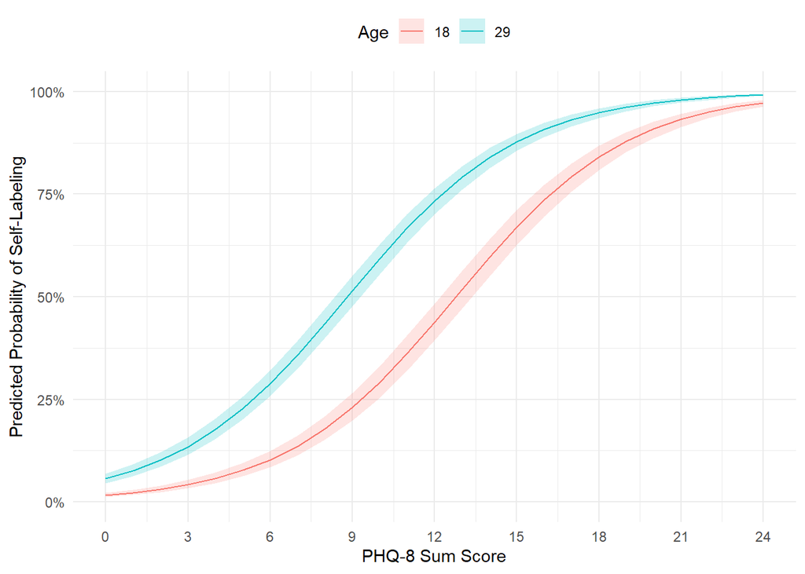

```r
predictions(model, newdata = datagrid(phq_8_sum = 0:24, age = c(18, 29))) %>%
  ggplot(aes(x = phq_8_sum, y = estimate, color = factor(age), fill = factor(age))) +
  geom_ribbon(aes(ymin = conf.low, ymax = conf.high), alpha = .2, color = NA) +
  geom_line() +
  scale_x_continuous(breaks = seq(0, 24, 3)) +
  scale_y_continuous(labels = scales::label_percent(), limits = c(0, 1)) +
  labs(x = "PHQ-8 Sum Score", y = "Predicted Probability of Self-Labeling", color = "Age", fill = "Age") +
  theme_minimal() +
  theme(legend.position = "top")
```

It’s the same pattern!